# Stats with R - Project

Vivien Tomacsek

# School diversity in the USA: 1994 - 2016

Data is from TidyTuesday https://github.com/rfordatascience/tidytuesday/tree/master/data/2019/2019-09-24

```
## --- Compiling #TidyTuesday Information for 2019-09-24 ----
```

```
## --- There is 1 file available ---
```

```
## --- Starting Download ---
```

```
## --- Download complete ---
```

## Exploratory data analysis

The 2019-09-24 TidyTuesday dataset is about school diversity in the USA. Diversity meaning the diversity in the ancestry of the students.

The datapoints are either from 1994-1995 or 2016-2017 school year.

First, look at the number of students by state and by school year.

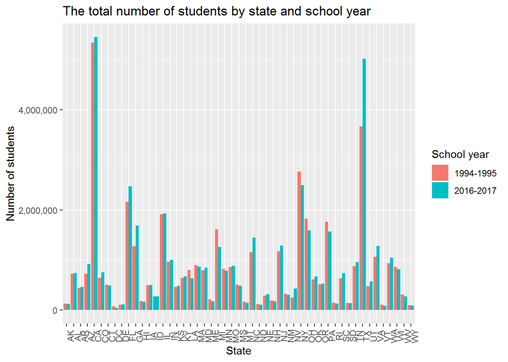

California and Texas have the largest amount of students in the dataset, which is not surprising given that these are the most populous states of the USA.

Texas also shows the highest growth in the number of students, which again parallels demographics data not analysed here (the population of Texas increased by more than 10 million since 1990).

It should also be noted that there is no data from 1994-1995 from Idaho.

We should check if there is any visible association between the locale of the school and its diversity.

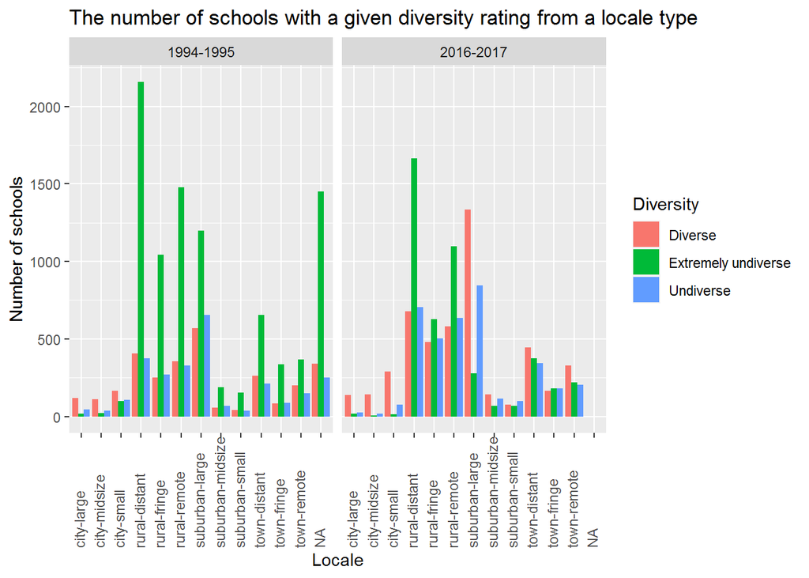

Let’s see how ethnic diversity changed in some states’ schools.

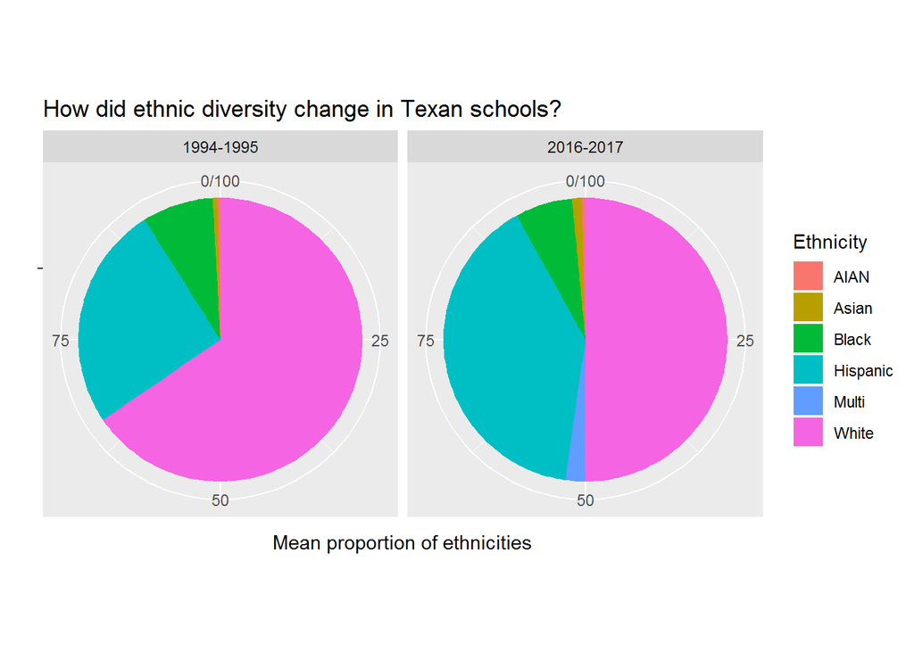

The proportion of Hispanic students increased considerably in Texas.

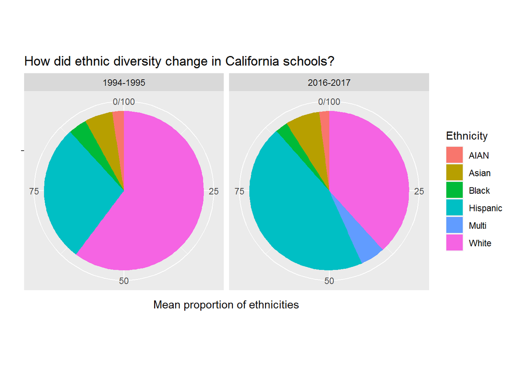

The proportion of Hispanic students also increased in California. This may be due to immigration from Central and South America.

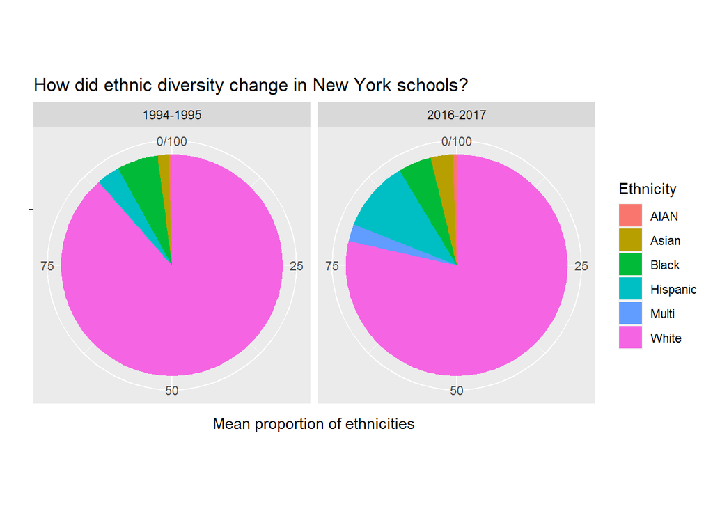

The proportion of Hispanic students also seem to have grown in New York.

## Hypothesis testing

I hypothesize that the rate of Black students increased from the 1994-1995 to the 2016-2017 school years. Since the distributions are not normal, but the homoscedasticity is not violated, Wilcoxon test is applied.

```
##
##  Anderson-Darling normality test
##
## data:  black_st94$Black
## A = 2509.5, p-value < 2.2e-16
```

```
##
##  Anderson-Darling normality test
##
## data:  black_st16$Black
## A = 2408.7, p-value < 2.2e-16
```

```
## Levene's Test for Homogeneity of Variance (center = median)
##       Df F value Pr(>F)
## group  1  0.0596 0.8077
##       98
```

```
##
##  Wilcoxon signed rank test with continuity correction
##
## data:  black_st94$Black and black_st16$Black
## V = 26369141, p-value < 2.2e-16
## alternative hypothesis: true location shift is not equal to 0
```

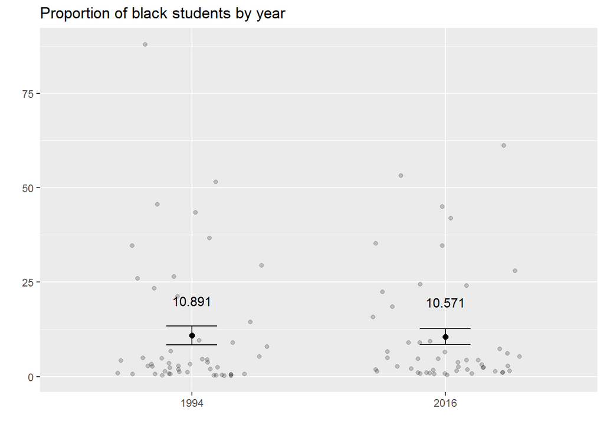